# Projet Info-Stat UE MI0A403T

LE PAGE Gael (25%), OSMAS Thomas (25%), OVONO ETOUBEMBE Julfab williarde (25%), PHAM HUU Dang (25%)

# 1 Base de données

## 1.1 Construction de la base de données

La base de données a été construite à l’aide de SQLite3 et d’un script Python permettant d’automatiser l’ensemble du processus. Elle repose sur une architecture relationnelle composée de six tables principales :

- REGIONS : contient les codes et noms des régions.
- DEPARTEMENTS : identifiés par leur code, associés à une région via une clé étrangère.
- COMMUNES : informations géographiques et démographiques (population, superficie, densité, altitude, latitude, longitude).
- CLIMAT_MENSUEL : données climatiques moyennes (pluie, températures, vent, ensoleillement, rayonnement).
- STATION : stations de mesure de la qualité de l’air, avec leur typologie (trafic, fond urbain…) et leur localisation.
- MESURE_POLLUTION : mesures journalières des polluants (NO₂, O₃, PM10…), associées à une station.

Les types de données (INTEGER, REAL, TEXT) ont été choisis pour correspondre à la nature des variables. Les contraintes PRIMARY KEY, FOREIGN KEY et ON DELETE CASCADE assurent l’intégrité référentielle entre les tables et garantissent la cohérence des relations (région → département → commune → station → mesures).

La création et l’alimentation de la base ont été automatisées via une fonction Python factorisée (creation_base()), qui :

- crée une table à partir d’une requête SQL,
- lit un fichier CSV,
- vérifie la présence des colonnes attendues,
- insère les données correspondantes.

Cette factorisation permet d’éviter la duplication de code et facilite l’ajout ou la modification de tables.

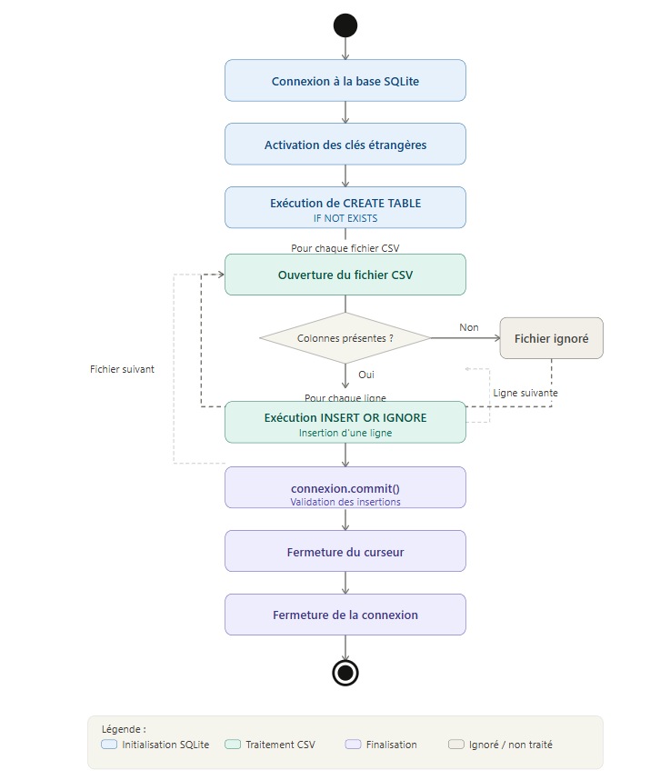

## 1.2 Extractions de tables depuis la base de données

L’extraction des données nécessaires aux analyses statistiques a été réalisée à l’aide d’un script Python dédié (creationCSV.py). Ce script automatise l’ensemble du processus en :

- exécutant une requête SQL correspondant à chaque problématique,
- récupérant les résultats sous forme de tuples Python,
- générant automatiquement un fichier CSV contenant les colonnes et les observations extraites.

Chaque problématique du projet est associée à une requête SQL spécifique. Ces requêtes mobilisent plusieurs tables de la base (COMMUNES, STATION, MESURE_POLLUTION, CLIMAT_MENSUEL)

Pour la problématique 1, l’objectif était d’étudier la relation entre les concentrations de NO₂ et la force du vent pour les stations de Toulouse. La requête SQL sélectionne :

- le nom et le type de station,
- la valeur du polluant NO₂,
- la date (jour, mois, année),
- la force du vent moyenne,

uniquement pour Toulouse et pour les mois d’octobre, novembre et décembre 2022.

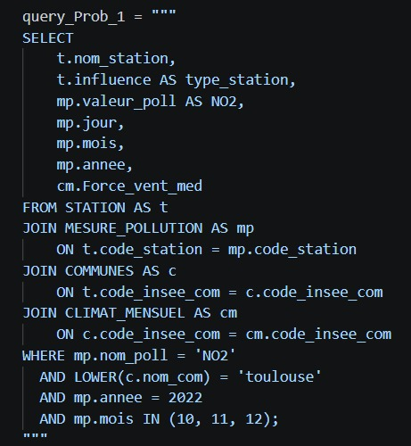

La problématique 2 vise à analyser l’influence des variables climatiques sur la typologie du territoire. La requête SQL sélectionne :

- la typologie du territoire (densite_cat),
- les coordonnées géographiques,
- l’altitude,
- les variables climatiques (pluie, températures, vent, insolation, rayonnement).

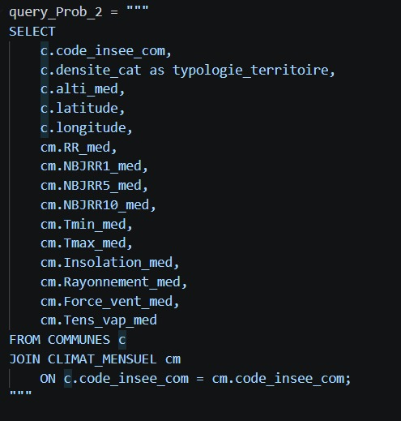

Pour la problématique 3, l’objectif était d’identifier les facteurs géographiques et climatiques permettant de distinguer les différents types de territoires. La requête SQL combine les tables COMMUNES et CLIMAT_MENSUEL afin d’obtenir :

- la typologie du territoire,
- l’altitude,
- les coordonnées géographiques,
- les variables climatiques pertinentes.

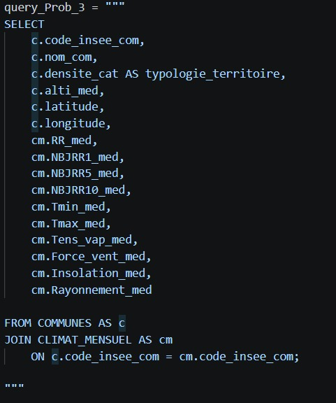

La problématique 4 étudie l’effet conjoint de la typologie du territoire, des conditions météorologiques et des émissions locales sur les concentrations de polluants. - La requête SQL associe :

- les mesures journalières de pollution,
- les variables climatiques,
- la typologie du territoire,
- les caractéristiques géographiques (latitude, longitude, altitude).

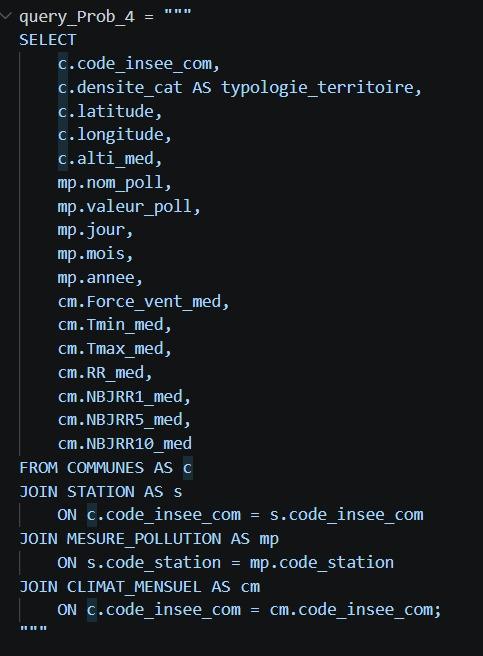

## 1.3 Enrichissement de la base de données à partir de nouvelles données trouvées sur le web (facultatif)

Dans le cadre de ce travail, aucun jeu de données supplémentaire n’a été ajouté.

Ce choix se justifie par :

- la richesse des données déjà fournies (pollution, climat, géographie, typologie),
- la volonté de maintenir une base cohérente et homogène,
- l’objectif de se concentrer sur la qualité des requêtes SQL et des analyses statistiques.

La base repose donc exclusivement sur les données officielles fournies, garantissant une structure claire et adaptée aux problématiques étudiées.

# 2 Statistique descriptive

## 2.1 Identification de problématiques statistiques

1. Existe-t-il un lien entre la concentration de NO2 et la force du vent dans une station trafic et une station fond urbain à Toulouse ?
2. Comment le climat (pluie, température, ensoleillement, vent) influence‑t‑il le type d’occupation du territoire (zones urbaines, rurales, dispersées) dans une région ?
3. Quels facteurs climatiques et géographiques permettent de distinguer les territoires urbains, les territoires ruraux et les territoires dispersés dans la région étudiée ?
4. Dans quelle mesure la structure du territoire (urbain, rural, dispersé) modifie‑t‑elle la dispersion des polluants atmosphériques en fonction des conditions météorologiques (vent, température, pluie) ?